# SIB workshop “Bioinformatics of long read sequencing” hands-on

July 5th, 2016. University of Bern.

https://www.isb-sib.ch/training/upcoming-training-events/training/2016-07-longreads

## <sub>Contributors</sub>

<sub>Amina Echchiki, Kamil Jaron, Julien Roux: Evolutionary Bioinformatics Group, UNIL and SIB</sub>

<sub>Walid Gharib: Interfaculty Bioinformatics Unit, UNIBE and Training and Outreach team, SIB</sub>

## Introduction

The aim of this practicals session is to get your hands on real long reads sequencing data generated from two different technologies:

- Oxford Nanopore [MinION](https://www.nanoporetech.com/products-services/minion-mki)
- Pacific Biosciences [RS II](http://www.pacb.com/products-and-services/pacbio-systems/rsii/)

The biological material that was sequenced using these two platforms is DNA from the [lambda phage](http://en.wikipedia.org/wiki/Lambda_phage). This is not a particularly interesting genomic material for a long read sequencing study, since such a small genome can be assembled easily with short Illumina reads (check [this](https://peerj.com/articles/2055/) publication for example). However, its genome is small (48kb), which makes it feasible to run an analysis yourself during the limited time of this practicals session.

You will go through different steps, which include the extraction of reads from their native encoding formats ([HDF5](http://en.wikipedia.org/wiki/Hierarchical_Data_Format)), quality control, *de novo* genome assembly, and a mapping of reads to a reference genome.

After DNA fragmentation, the **MinION** library is prepared by ligating adapters to the double-stranded DNA fragments. One side receives a Y-form adapter, and the other side a hairpin-form adaptor. The adapters are conjugated with motor proteins that help control the translocation speed of DNA through the pore. When the Y-form adapter approaches the pore, one strand starts to be sequenced. This sequence is called *template*. After the hairpin-form adapter is sequenced, the *complement* sequence is read. The template and complement sequences are sometimes called *1D reads*. The consensus of template and complement sequences is called a *2D read*. An illustration of the protocol is provided in this [figure](http://www.genetics.org/content/202/1/37):

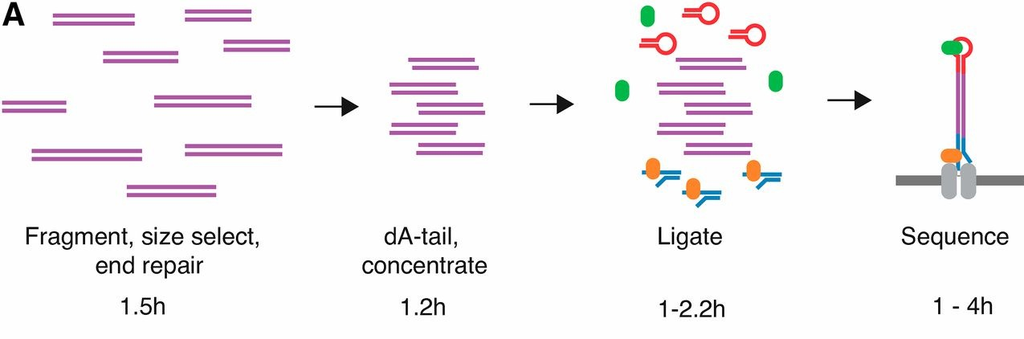

For **PacBio** sequencing (or **SMRT** sequencing), hairpin-form adapters (SMRTbell) are ligated on both sides of double-stranded DNA fragments, forming a circular sequence. Circular sequences attach to the bottom of the SMRT cell wells, and are continuously read, and a movie is recorded. Nowadays, the total length of movie allows to record up to 75,000 nucleotide basecalls. This implies that short DNA fragments will be read many times, while long fragments may be read just one or twice. The complete sequence is called a *polymerase* read. After the adapter sequences are removed, the sequence is split into *subreads*. The consensus of subreads is called a *circular consensus read* or *read of insert*.

[figure not shown]

## How to connect to the Vital-IT cluster?

By now, you should have received a username and password to access the high performance computing cluster of the SIB (Vital-IT). Obviously, you can use your own Vital-IT account if you have one.

Even if you have access to another cluster, the data required for this practical is stored on Vital-IT so all participants should connect to vital-IT.

In order to connect to the cluster and set up your working directory follow the next steps:

### For Linux / Mac OSX users

In a terminal, type `ssh <username>@prd.vital-it.ch`. You will be prompted to input your user password (`<username>@prd.vital-it.ch's password:`). Type in your password (you will not see what you are typing) and press Enter.

You are in! Jump to Setting up your working directory.

### For Windows users

You should first install a ssh client (e.g., `PuTTY`). If you already have one, we assume you know how to use it. Connect to Vital-IT and jump to Setting up your working directory.

### Setting up your working directory

- On Vital-IT, you must read and write files in the “scratch” directory. Move to `/scratch` weekly directory:

  ```bash
  cd /scratch/beegfs/weekly/
  ```

Be careful, files in this folder are erased after a week. At the end of the practicals, if you want to keep your results, you need to back-up the data, for example in a compressed tarball that you move to your home or archive folder, or to another computer.

- Create your own directory:

  ```bash
  mkdir <username>; cd <username>
  ```

- You will always be working from this directory. Before launching commands please be sure that you are located in the right directory by typing: `pwd`. The expected output is: `/scratch/beegfs/weekly/<username>`

### Submitting commands to the cluster

**It is not allowed to launch any calculation on the frontal machine where you are connected (`prd.vital-it.ch`)**. You need to submit each job for batched execution through a job scheduler that will dispatch it on the cluster nodes. For example:

```bash
bsub '[my command line here]'
```

Or, better, write your commands in a script and submit it with:

```bash
bsub < script.sh
```

## 1. Read extraction

### Formats

The output of MinION and PacBio RS II are stored in Hierarchical Data Format, that is basically an archive format (such as `.zip` or `.tar`), but allowing a very quick access to its content (you can find details on [wikipedia](https://en.wikipedia.org/wiki/Hierarchical_Data_Format)). Those files include all details about reads and basecalling. What you will need for this practical are just the sequences and their qualities, that can be stored in a simple `.fastq`.

The files saved in Hierarchical Data Format can be explored using HDF5 command-line tools:

```bash
h5dump <HDF_file> | less
h5stat <HDF_file> | less
```

#### fast5

The MinION basecaller produces one file per read, which includes the time series of the measured ionic current used for basecalling, the basecalled template and complement read sequences, and the consensus 2D reads.

#### bas.h5 and bax.h5

The PacBio RS II system produces three `bax.h5` files and a `bas.h5` per SMRT cell. The three `bax.h5` files correspond to the first, second and third part of the movie capturing the SMRT cell. The `bas.h5` file contains metadata. PacBio announced a change of data format to more classcial `.bam` files for the next platform (called *Sequel*), however all data produced by the RS II platform will be still in the `.h5` formats you are going to work with.

### Tools

All used tools are already installed on Vital-IT. Before the first use, you will just need to load the package.

**Poretools** is a toolkit for working with sequencing data from MinION, for the purposes of quality control and downstream analysis. It operates directly on the native `.fast5` format and provides format conversion utilities and data exploration tools. Software usage is detailed in the [documentation](http://poretools.readthedocs.io/en/latest/).

**pbh5tools** is a set of python scripts to extract `.fasta` and `.fastq` from `bas.h5` and `bax.h5` files. These scripts allow filtering based on error rate, read length and read type. Source code is available on [GitHub](https://github.com/PacificBiosciences/pbh5tools) and software usage is detailed in [documentation](https://github.com/PacificBiosciences/pbh5tools/blob/master/doc/index.rst).

### Extraction of MinION reads

First, create a working directory for MinION raw reads and create links to the raw sequencing files.

```bash
mkdir -p lambda_minion/fast5/
ln -s /scratch/beegfs/monthly/SIB_long_read_workshop/MinION_lambda_reads/*.fast5 \
  lambda_minion/fast5/
```

Can you guess what each file corresponds to? How many reads has this sequencing experiment produced?

You will convert the MinION raw reads from their `.fast5` to a more classical and readable `.fastq`. This can be done with the `poretools fastq` utility. To find out which options to use, please refer to the [documentation](http://poretools.readthedocs.io/en/latest/content/examples.html#poretools-fastq), or type `poretools fastq -h`. For now, we are interested in extracting all types of reads (template, complement and 2D), so check out the option `--type`. Be careful, the output `.fastq` file is written in the standard output, so you need to save the standard output to a file using `>`. For example:

```bash
module add UHTS/Analysis/poretools/0.5.1
poretools fastq [...] > lambda_minion/all_reads.fastq
## And even better you can add a step to compress the output file:
gzip -9 lambda_minion/all_reads.fastq
```

**Remember, that it is not allowed to launch your command on the frontal machine!** You need to write the above commands in a bash script (called for example `minion_extract.sh`) that you will submit to the cluster with `bsub` (see Submitting commands to the cluster):

```bash
bsub < minion_extract.sh
```

Have a look at the `.fastq` file created, using `less` or `nano`. Looking at header lines (starting with a `@`), do you identify which reads are 2D, template or complement reads? Do you identify which lines correspond to the quality scores (their header is a `+` sign).

Focus on a 2D read chosen at random. Look for the corresponding template and complement reads, which should be the next ones in the file (or you can search for the unique hash at the beginning of the header, which is common between 2D, template and complement reads).

Do the quality scores seem to be improved in 2D reads? You can refer to [this wikipedia page](http://en.wikipedia.org/wiki/FASTQ_format#Encoding) for help on the PHRED quality scores in `.fastq` files.

You will not do this today, but for basic quality control of the reads, you can also launch the `fastqc` software (widely used for Illumina data) on this `fastq` file. The reported statistics are correct, just keep in mind that warning flags in the report are meaningful for short reads, and sometimes not very informative for long reads.

If you are lost, you can get extracted MinION reads by executing the following script. While the script is running, have a look at it to understand what is done.

```bash
bsub < /scratch/beegfs/monthly/SIB_long_read_workshop/scripts/1_Extraction_MinION.sh
```

### Extraction of PacBio RS II reads

First, create a working directory for raw reads and create links to the raw sequencing files.

```bash
mkdir -p lambda_RSII/raw_reads/
ln -s /scratch/beegfs/monthly/SIB_long_read_workshop/RSII_lambda_reads/*.h5 \
  lambda_RSII/raw_reads/
```

How many SMRT cells do we have?

Extract PacBio subreads using `bash5tools.py` from `pbh5tools`. Again, refer to the [documentation](https://github.com/PacificBiosciences/pbh5tools/blob/master/doc/index.rst). The commands will look like this:

```bash
module add UHTS/PacBio/pbh5tools/0.8.0

bash5tools.py <file.bas.h5> \
  --outFilePrefix lambda_RSII/<prefix_for_extracted_reads> \
  --readType subreads \
  --outType fastq
# compress the output file:
gzip -9 lambda_RSII/[prefix.fastq]
```

Put the full command in a script and submit it using bsub:

```bash
bsub < pacbio_extract.sh
```

How many subreads were produced?

If you are lost, you can get extracted PacBio reads by executing

```bash
bsub < /scratch/beegfs/monthly/SIB_long_read_workshop/scripts/1_Extraction_RSII.sh
```

## 2. Genome assembly

Genome assembly with long reads is, just like the established assembly with short-reads, based on graph theory. But string graphs are used instead of De Brujin graphs, and instead of kmer decomposition, the graph of reads (nodes) and their overlaps (edges) is constructed.

### Tools

#### Canu

Canu is an assembler for noisy long-reads sequences. It is a fork of Celera with added modules for error correction and trimming of reads. Canu was designed for both MinION and PacBio data, and is one of the two leading assemblers for longs reads (together with Falcon). Canu has many parameters, which are not discussed on this workshop, but many details are given in the [manual](http://canu.readthedocs.io/en/stable/).

#### Miniasm

Miniam is lightweight assembler. It very fast, but for a cost of simplicity and low parametrization. It can used as a first proxy of the data content, but for a final assembly, another assembler should be considered. As a first step, the overlap of reads is computed in a separated step using a standalone program called `minimap`.

### MinION

You will assemble the lambda phage genome using only the 2D reads. 1D reads are of substantially lower quality, so you would like to avoid using them if there are enough 2D reads. Since this is the case (~3,000 reads, i.e., coverage of ~500X), the assembly should be trivial: the genome is 48.8 kb and we have some reads of 20kb. We expect only one contig!

#### Canu

Choose the appropriate parameters to run [Canu](http://canu.readthedocs.io/en/latest/commands/canu.html):

```
module add UHTS/Assembler/canu/1.3; # load canu software

usage: canu -p <assembly-prefix>    # use a specified prefix to name canu output files
            -d <assembly-directory> # use a specified prefix for output directories
            genomeSize=<number>     # expected genome size
                  useGrid=false           # disables automatic submission to cluster
            -nanopore-raw           # specifies that ONT MinION data are used
            <data in fastq format>
```

Put the full command in a script and submit it using bsub:

```bash
bsub < minion_assembly_canu.sh
```

The output directory contains many files. The most interesting ones are:

- *.correctedReads.fasta.gz : file containing the input sequences after correction, trim and split based on consensus evidence.
- *.trimmedReads.fastq : file containing the sequences after correction and final trimming
- *.layout : file containing informations about read inclusion in the final assembly
- *.gfa : file containing the assembly graph by Canu
- *.contigs.fasta: file containing everything that could be assembled and is part of the primary assembly

How many contigs were produced? Does the total size seem to match your expectations?

During our tests, the assembly did not always work. Sometimes the job was killed by the cluster, please check carefully the standard output and error files. We think that the memory requirement of Canu might be too big for some machines of the cluster. If this happens to you, rerun the job using the queue `dee-hugemem` instead of the queue `priority`. It night be useful to increase the amount of memory requested with the options `-v 20000000 -R "rusage[swp=20000]"` and `-M 10000000 -R "rusage[mem=10000]"`. If this still does not work, you can see a successful run that we pre-computed in the folder `/scratch/beegfs/monthly/jroux/tp_long_reads/lambda_minion/canu/`.

### PacBio RS II

One PacBio RS II SMRT cell produces between 0.5 and 1 gb. This roughly correspond to a 10,000x coverage of the lambda phage genome which is clearly an overkill. We can decrease the computational load by using a subset of only a few thousand reads for the assembly.

Go to the directory including the extracted PacBio reads and extract a subset of the first 3,000 reads.

```bash
zcat RSII_reads.fastq.gz |
  head -12000 |
  gzip -9 >
  RSII_reads_subset.fastq
```

The assembly step is now analogous to the assembly of MinION data.

Modify the command performing `Canu` assembly for PacBio data. Change the type of input reads to `-pacbio-raw`, the name of the input file and the name of output folder, and launch the assembly.

What is the length of the resulting assembly? Is there anything weird going on?

#### Bonus: Miniasm

Since the assembly with Canu does not seem to be successful, you will try a different assembler, `miniasm`.

You first need to compute the overlaps of reads using `minimap`. As recommended in the [documentation](https://github.com/lh3/miniasm), put the following command and parameters in your submission script:

```bash
minimap -S -w 5 -L 100 -m 0 <reads.fq> <reads.fq> |
  gzip -9 >
  <overlaps.gz>
```

Then, to perform the assembly using `miniasm`:

```bash
module add UHTS/Analysis/minimap/0.2.r124.dirty; # load module minimap
module add UHTS/Analysis/miniasm/0.2.r137.dirty; # load module minimap

miniasm -f <reads.fq> <overlaps.gz> > <contigs.gfa>
## convert .gfa to .fasta
awk '/^S/{print ">"$2"\n"$3}' <contigs.gfa> | fold > <contigs.fa>
```

Put these commands in a script and submit it using bsub:

```bash
bsub < RSII_assembly_miniasm.sh
```

The size of the `.fasta` file in bytes corresponds to the number of nucleotides, newline characters and characters in headers. This is useful to roughly estimate the length of an assembly. Ortherwise you can remove the header with tail and count the number of nucleotides: `tail -n+2 lambda_RSII/miniasm/contigs.fa | wc -m`

What do you think about the length of this assembly?

If you are lost, you can get the assembly based on PacBio reads by executing:

```bash
bsub < /scratch/beegfs/monthly/SIB_long_read_workshop/scripts/2_Assembly_RSII.sh
```

## 3. Quality of assemblies

`Canu` produces a `.html` report for every performed step. You can find there the amount of reads after correction, filtering, etc. Miniasm, however does not provide such a report, therefore you will use `Quast` to estimate basic statistics of the all assemblies in a comparable format, and allow the comparison to the lambda phage reference genome to inspect their quality.

### Tools

#### Quast

Quast is a tool to evaluate genome assemblies. It provides a PDF report providing metrics on contigs. It can also be used for comparison between assemblies, or to compare a *de novo* assembly to a reference genome. Here are the [paper](http://www.ncbi.nlm.nih.gov/pmc/articles/PMC3624806/), the [GitHub page](https://github.com/ablab/quast) and the manual.

#### MUMmer

MUMmer is a software for rapidly aligning entire genomes, whether in complete or draft form. It can generate visualizations, such as dot plots. Here is the [documentation](http://mummer.sourceforge.net/manual/).

### Downloading the lambda phage reference genome

```bash
mkdir reference/
cd reference/
wget ftp://ftp.ncbi.nlm.nih.gov/genomes/Viruses/Enterobacteria_phage_lambda_uid14204/NC_001416.fna
# change to a clearer name:
ln -s NC_001416.fna lambda_ref_genome.fa
```

### Running Quast

The command in your submission script should look something like this:

```bash
module add UHTS/Quality_control/quast/4.1  # load quast module


quast.py
  -R <path to reference genome>
  <path to Canu MinION assembly>
  <path to Canu PacBio assembly>
  <path to Miniasm PacBio assembly>
```

Put these commands in a script and submit it using bsub:

```bash
bsub < quast.sh
```

The output is a directory, typically `quast_results/<date_of_launch>`, containing several files including a report in PDF format. Copy it to your local machine using `scp`: `scp username@prd.vital-it.ch:[path_to_file_on_vital_it] [path_to_file_on_laptop]`

What do you notice in this report? What did go wrong with the PacBio Canu assembly? Is the Miniasm assembly better? Compare the Canu assemblies made wiht both MinION and PacBio data: hwo does the error and indel rates compare?

If you are lost, you can get the quality report for your assemblies by executing:

```bash
bsub < /scratch/beegfs/monthly/SIB_long_read_workshop/scripts/3_AssemblyQuality.sh
```

### Bonus: getting further

It would be interesting to know more precisely what is going on with PacBio assemblies. * The software `Mauve` (see [website](http://darlinglab.org/mauve/user-guide/introduction.html)) could be interesting, but it is GUI only, so you need to install it on your laptop.  
* It is probably a good idea to generate a dot plot to visualize and compare assemblies. This can be done with the `MUMmer` software. The command below will find all maximal unique matches (-mum) between the assemblies on both the forward and reverse strands (-b) and report all the match positions relative to the forward strand (-c). The output lists all of the matches between the two input sequences.

```bash
mkdir mummer/

module add UHTS/Analysis/MUMmer/3.23; # load quast module

mummer -mum -b -c <assembly_1.fa> <assembly_2.fa> >
  mummer/<assembly_1_vs_2.mums>
```

To generate a dotplot of all the matches between two sequences:

```bash
mummerplot -postscript -p <assembly_1_vs_2> <assembly_1_vs_2.mums>
```

Write a script to perform the comparison of all assemblies to the reference genome:

```bash
bsub < mummer.sh
```

Download the postscript dot plots to your computer with `scp`. What do you think of the dot plots? Check this [cheat sheet](http://mummer.sourceforge.net/manual/AlignmentTypes.pdf) for interpreting dot plots. Is the problem with the PacBio Canu assembly really important? Can you guess from this plot what went wrong when passing the Miniasm assembly through Quast?

## 4. Bonus: mapping reads to a reference genome

### Tools

#### NanoOK

This tool allows to perform multiple analyses over MinION data, including the extraction of read sequences from `.fast5` files, their alignment to a reference, and the generation of a summary report of QC and mapping statistics. This software was designed for MinION data, but it is easy to “hack” it to use PacBio reads. Source code can be found on [GitHub](http://github.com/TGAC/NanoOK) and software usage is detailed in the [documentation](http://documentation.tgac.ac.uk/display/NANOOK/NanoOK).

#### LAST

LAST finds similar regions between sequences (local alignment). It is faster than BLAST and can handle largeer datasets. See the project [website](http://last.cbrc.jp/).

### MinION

To map the reads to the reference genome of the lambda phage using the `LAST` aligner, the reference sequence first needs to be indexed. The `-Q 0` tells LAST to expect a fasta file.

```bash
cd reference/
module add UHTS/Analysis/NanoOK/0.72
lastdb -Q 0 lambda_ref_genome lambda_ref_genome.fa
cd ..
```

Now launch the alignment with `LAST` (default aligner) using the `nanook align` utility. NanoOK expects a fasta file for each read, in a folder called `fasta/`, so we need a bit of file manipulation first. The commands in your submission script should look like this:

```bash
mkdir lambda_minion/fasta/

# Extract the read headers and sequences only
zcat lambda_minion/all_reads.fastq.gz | awk 'NR%4==1||NR%4==2' \
  > lambda_minion/all_reads.fasta

# Convert header according to fasta specifications
perl -p -i -e 's/^@/>/g' lambda_minion/all_reads.fasta

# split each read in a different file
nanook_split_fasta -i lambda_minion/all_reads.fasta -o lambda_minion/fasta/

# move reads to folders reflecting their type: 2D, template, complement
mkdir lambda_minion/fasta/2D
mkdir lambda_minion/fasta/Complement
mkdir lambda_minion/fasta/Template
find lambda_minion/fasta/ -maxdepth 1 -name \*_2d.fasta \
  -exec mv {} lambda_minion/fasta/2D/ \;
find lambda_minion/fasta/ -maxdepth 1 -name \*_template.fasta \
  -exec mv {} lambda_minion/fasta/Template/ \;
find lambda_minion/fasta/ -maxdepth 1 -name \*_complement.fasta \
  -exec mv {} lambda_minion/fasta/Complement/ \;

# Launch the alignment
nanook align -s lambda_minion -r reference/lambda_ref_genome.fa
```

What directories have been created? What do they contain? Look at one randomly chosen alignment file. What is striking?

* It is possible to specify to `nanook align` the alignment parameters to be used with `LAST`, with the `-alignerparams` option. By default the parameters are `-s 2 -T 0 -Q 0 -a 1`.

- If you want, you can use the lambda phage genome assembly you created today as a reference for the alignment.
- You can try to align reads with other aligners. For example to use `BWA-MEM`, you first need to create the index of the reference sequence (`bwa index reference.fasta`). Then you can relaunch `nanook align` with the `-aligner bwa` option.

### Statistics and QC report

Launch the generation of the NanoOK alignment report including QC and alignment statistics using the `nanook analyse` utility. A PDF file should be created in the `latex_last_passfail/` folder. If it’s not the case, you can generate it yourself with the `pdflatex file.tex` command (press enter every time the program prompt you with a question).

```bash
nanook analyse -s lambda_minion -r reference/lambda_ref_genome.fa
pdflatex lambda_minion/latex_last_passfail/lambda_minion.tex
```

Download the report to your laptop, and take some time to read and understand it. Here are a few questions that will guide you: * What size is the longest template read? Is that surprising? * What does the N50 values indicate us? Is that consistent with the size of the DNA fragments used to create the MinION library (~8kb)? * What is most common error type within reads? * In comparison, the typical error rate reported for the Illumina sequencing technology is around 0.1%. For Sanger sequencing, it can be as low as 0.001%… An interesting comparison of error rates across platforms was recently [published](http://bib.oxfordjournals.org/content/17/1/154). * Why is the alignment rate of 2D reads higher than those of template and complement reads? * Which are the most accurate: shortest or longest reads? * Have a look at the coverage plot. There is a “bump” in coverage around 45kb. This corresponds to some control spike-in DNA that was added during library preparation (more precisely around 3.6kb of a region of the lambda phage genome, with a single mutation G45352A). Can additional variation be explained by GC content differences? * Have a look at the k-mer over and under-representation analysis. What sort of k-mers are under-represented in 2D reads? Is that expected given how the technology works?

### PacBio RS II

It is quite easy to redo the above steps with PacBio data. Do it if you have time ;-)